# 20.20. Исправленная индивидуальная геометрия КТ/FEM Георгия

**Редакция от 11 октября 2026 года. Наружный контур заново построен по КТ; выполнен новый прямой FEM-расчёт.** Автор уточнил ориентацию боковых сборок и токовых контактов и потребовал полного сечения соединения цилиндров рук с телом. Предыдущая геометрия этим условиям не соответствовала. Численные результаты 33.22 от 8 октября сохранены как исторический расчёт и не относятся к настоящей геометрии. Геометрические и алгебраические проверки выполнены; критерий сеточной точности не выполнен. Геометрия закреплена как общий вход. Абсолютные FEM-импедансы остаются исследовательскими; они не разрешают количественную инверсию сопротивлений.

## 1. Входы и последовательность

Для подготовки конечноэлементной модели (FEM) использованы новая наружная поверхность полного статического КТ-тома и четыре маски: сердце, лёгкие, кости и жир. Остальной объём представляет мягкотканный фон. Маски получены автоматически TotalSegmentator 2.18; независимая точность границ не установлена. КТ снята на глубоком вдохе с задержкой дыхания и относится к другой сессии, чем Scorpion v2. Динамическая КТ сердца не подменяет полный том грудной клетки.

Контур выделен из КТ по порогу −450 HU. Тонкие внешние фрагменты удалены двумерным размыканием радиусом два вокселя; затем в каждом срезе выбрана основная компонента, выполнено замыкание радиусом один воксель и заполнение внутренних полостей. Контур визуально сопоставлен с КТ на всех 280 аксиальных срезах: стол отделён от тела. На отдельных срезах сохраняются небольшие поверхностные выступы, происхождение которых не установлено; их влияние на локальный контакт и расчёт пока не отделено от других источников погрешности. Это автоматическая реконструкция с геометрическим контролем; независимая анатомическая точность не установлена. Прежнее замыкание радиусом 10 мм не применяется. Четыре внутренние маски сохранены из полной автоматической сегментации.

Порядок данного этапа: проверить сечения исходной поверхности → подобрать заглубление цилиндров → объединить объёмы и проверить поверхность → перенести центры и построить контакты → построить новые объёмные сетки → выполнить прямые FEM-расчёты и сценарии смещения. Выполнены геометрические этапы, новая сетка, прямой расчёт и сценарии ошибки установки ТЕПС. Полный поиск общего центра боковых сборок и новая инверсия сопротивлений ещё не выполнены.

**Таблица 1.** Изменение наружного контура и влияние сокращения числа граней. Расстояния вычислены по 15 тысячам воспроизводимо выбранных точек каждой поверхности. Их максимум не является гарантированной максимальной ошибкой всей поверхности. Опорная поверхность построена по исходной КТ-маске; упрощённая поверхность используется сеточным генератором. После экспорта STL выполнена ограниченная локальная коррекция пересекающихся граней с сохранением топологии. Окончательный скрипт повторно дал побайтно совпадающие маску и поверхности.

| Показатель | Значение |
| --- | --- |
| Объём тела до добавления цилиндров, мл | 35082 |
| Объём прежней поверхности, мл | 35333 |
| Выборочное расстояние прежняя поверхность → новый КТ-контур, максимум, мм | 11,302 |
| Выборочное расстояние новый КТ-контур → прежняя поверхность, максимум, мм | 7,5247 |
| Выборочное расстояние исходный контур → полигональная сетка, максимум, мм | 0,72018 |
| Выборочное расстояние полигональная сетка → исходный контур, максимум, мм | 0,67093 |

## 2. Полное соединение цилиндров рук

Автор сообщил обхват 37 см для обеих рук на уровне токовых электродов и принял цилиндрическую модель. Радиус равен 370/(2π) = 58,8873 мм; площадь поперечного сечения — 10 894,16 мм². Прежние срезы наружной поверхности имели площади около 2721 и 3676 мм². Присоединение большого цилиндра только через эти срезы не обеспечивало требуемого полного контакта.

Новый подбор рассматривает плоскости, смещённые внутрь исходной поверхности на 0,5–109,5 мм с шагом 1 мм. В каждой плоскости центр круга выбирается в области, где всё сечение цилиндра помещается внутри тела, с геометрическим запасом 0,15 мм. Из допустимых кандидатов выбирается минимум суммы квадратов заглубления и сдвига центра относительно исходного среза. Это геометрическое правило, а не восстановление анатомического положения плеча.

**Таблица 2.** Заглубления и сдвиги центров цилиндров относительно прежних срезов. Полное сечение находится внутри исходного объёма. Круг представлен 256-сторонним многоугольником; отличие его площади от площади круга составляет около 0,010%. При объединении добавлен внутренний нахлёст 0,5 мм. Цилиндры не выходят за исходные пределы по y и z; их продолжение по x является заданной моделью рук.

Итоговая поверхность замкнута, имеет одну связную компоненту и положительный объём 39106 мл. Самопересекающихся граней не обнаружено. Эти проверки подтверждают целостность поверхности и полноту выбранных сечений; точность реальной формы рук ими не установлена.

| Рука | Заглубление, мм | Сдвиг y, мм | Сдвиг z, мм | Площадь сечения цилиндра, мм² | Площадь многоугольника, мм² | Доля сечения внутри тела, % |
| --- | --- | --- | --- | --- | --- | --- |
| Правая (x < 0) | 23,5 | 14,221 | −12,166 | 10894 | 10893 | 100 |
| Левая (x > 0) | 16,5 | 14,596 | −1,2478 | 10894 | 10893 | 100 |

## 3. Контакты и продольные сборки

По уточнению автора в монтаже 1×4 единственный токовый контакт каждой руки перенесён с передней поверхности наверх, поворотом на 90°. В монтаже 2×2 добавлен диаметрально противоположный нижний контакт. Четыре измерительных контакта 1×4 расположены через 90°; измерительная пара 2×2 также повёрнута на 90° и расположена сверху и снизу по уточнению автора от 09.10.2026. В полной электродной модели (CEM) контакты одной электрической группы должны иметь общий потенциал.

Продольные расстояния контактов рук сохранены: 20 мм для измерительных и 120 мм для токовых от прежней плоскости обрезки КТ. Начало отсчёта не перенесено на заглублённое соединение. Эта плоскость является модельным ориентиром, а не измеренной анатомической точкой. Номинальные центры проверены на конечной поверхности с допуском 0,02 мм.

В системе координат LPS положительные оси x, y и z направлены соответственно влево, назад и к голове относительно испытуемого; их начало перенесено из КТ. Боковые сборки теперь ориентированы по z LPS — вдоль тела. Для всех размеров сохранён один иллюстративный центр y = 0, z = −210 мм; его фактическая локализация по эксперименту пока неизвестна. Центры A, M, N, B задаются на уровнях −L/2, −L/4, L/4, L/2 относительно общего центра, где L — номинальное расстояние между токовыми центрами в миллиметрах. Они проецируются на правую поверхность лучами вдоль +x LPS. Отрицательная сторона x соответствует правой стороне человека. Это геометрический пример, используемый для проверки направления; тройка прежних выбранных точек не используется вместо полного поиска.

**Рисунок 1.** Исправленная наружная поверхность и центры контактов. Монтаж 2×2 и другие размеры можно включить через легенду. Маркеры изображают центры, а не дискретизированные FEM-площадки. Для новой CEM-постановки принят номинальный диаметр контакта 5 мм и площадь 19,635 мм²; фактическая проводящая площадь Scorpion ещё не установлена.

[interactive chart not shown]

## 4. КТ-сечение по оси сборок

**Рисунок 2.** Продольное КТ-сечение y LPS = 0 мм: полный том и сборка 140 мм. Все размеры имеют один центр; меньшие сборки занимают внутренние участки той же оси. Метки A и B обозначают токовые центры, M и N — измерительные. Показаны маски лёгких, костей, сердца и жира; отсутствие ткани в данном сечении не означает отсутствия её маски в объёме. Использована интерполяция ближайшего соседа. Геометрическая поверхность и КТ могут различаться из-за обработки наружного контура; выборочные расстояния поверхностей приведены в таблице 1. Голубая линия отмечает первое пересечение лучей вдоль +x LPS с маской правого лёгкого; пунктиром показаны расстояния от наружной поверхности до этой линии. Направление выбрано для сопоставления с принятой проекцией электродов. Оно не является локальной нормалью к коже или кратчайшим расстоянием до лёгкого.

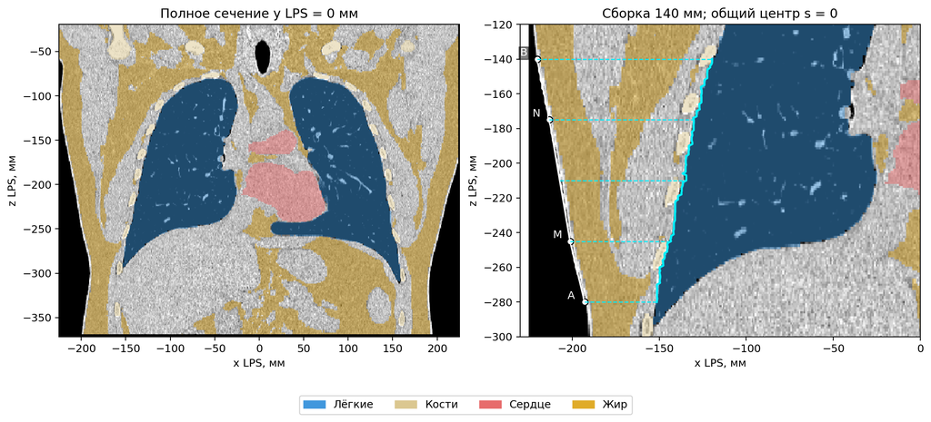

**Рисунок 2, дополнительная панель.** КТ и те же тканевые маски после выравнивания наружной поверхности. Для каждого смещения s начало луча перенесено на наружную STL-поверхность, а глубина d равна разности координаты x LPS и координаты поверхности на этом уровне. Перенос не растягивает луч: расстояния между границами и толщины анатомических элементов вдоль +x LPS сохранены с шагом 0,5 мм. Ось s, шаг 1 мм и общий центр совпадают с рисунком 3. Белая горизонтальная линия соответствует нулевой глубине, голубая — первой границе маски правого лёгкого. Вертикальные штриховые линии задают положения A, M, центра, N и B вдоль оси сборки. Цветные горизонтальные штриховые линии показывают глубину лёгкого в этих пяти положениях; подписи справа содержат обозначение и расстояние в миллиметрах. Кружки на голубой границе соединяют каждое положение с соответствующим уровнем глубины. Серые области вне доступного КТ или за срединной плоскостью x LPS = 0 не интерпретируются как мягкие ткани. Маски остаются автоматическими; расстояния зависят от их точности и обработки наружной поверхности. Это выровненное изображение реальной неоднородной анатомии в выбранном сценарии, а не плоская двуслойная модель или оценка электрической h.

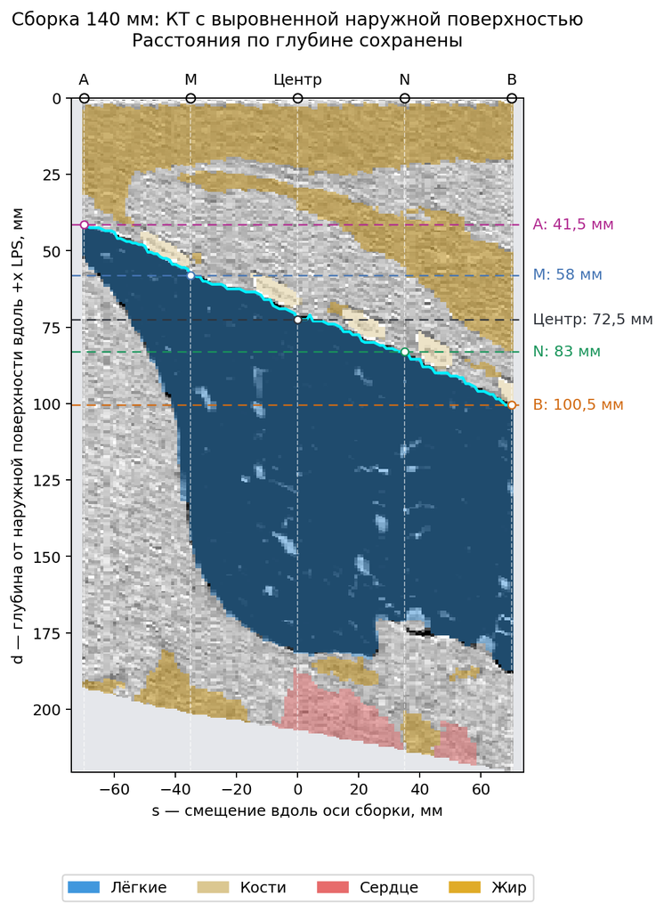

**Рисунок 3.** Профиль анатомического расстояния до маски лёгкого вдоль общей оси сборок. Смещение s отсчитывается вдоль z LPS от иллюстративного центра на уровне −210 мм: от −70 до +70 мм с шагом 1 мм. Положительное направление s соответствует направлению к голове. A, M, N и B — центры контактов сборки 140 мм. Расстояние d вычислено от наружной STL-поверхности до первого ненулевого вокселя маски лёгкого вдоль +x LPS; луч заканчивается на плоскости x LPS = 0, чтобы не подменить правое лёгкое левым. Шаг вдоль луча составляет 0,5 мм; ошибка такого поиска границы не превышает одного шага относительно границы дискретной маски. Погрешности сегментации, обработки контура тела и восстановления положения этим пределом не охвачены. Если лёгкое на луче отсутствует или поле КТ неполно, расстояние не назначается.

Профиль построен независимо от импеданса и сопротивлений. Он показывает пространственную неоднородность анатомии при данном примере положения. Электрически эквивалентная толщина h двуслойной модели пока не определена через этот профиль: способ такого сведения требуется проверить по индивидуальной конечноэлементной модели. Сплошная синяя линия представляет профиль d(s); вертикальные серые штриховые линии — положения электродов и центра. Горизонтальные цветные штриховые линии и кружки отмечают значения d в этих положениях; подписи справа показывают их в миллиметрах. При неопределённой глубине соответствующий горизонтальный уровень не проводится.

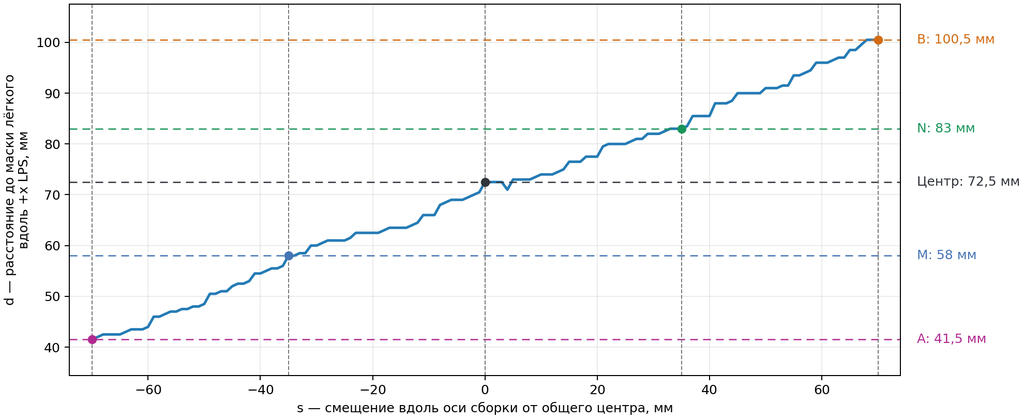

## 5. Полный перерасчёт положения и сопротивлений

Следующий этап — поиск общего центра по всей допустимой правой поверхности грудной клетки с проверкой размещения всех пяти размеров. Направление вдоль тела задаёт номинальную ориентацию; ошибку установки необходимо исследовать отдельно. Для каждого положения сопротивления мягкотканного фона, лёгкого и жира следует оптимизировать совместно либо вложенным поиском. Поиск положения при одной фиксированной тройке сопротивлений не заменяет эту обратную задачу. Цель — карта невязки и допустимых тканевых параметров по всей области, с оценкой геометрической и электрической неоднозначности. Это план следующего расчёта, а не выполненный результат.

Для новой поверхности построены новые объёмные сетки и материальные матрицы четырёх масок и фона. Контактные площадки и CEM-матрицы собраны заново для каждого проверяемого положения. Матрицы и оценки 8 октября не использованы. Проверки двух сеток, интегрирования, взаимности, сборки EIDORS и производных представлены ниже. Новая инверсия ещё требуется. Для двуслойного поиска в 33.21 приняты физиологически мотивированные литературные интервалы при 100 кГц. Их перенос на мягкотканный фон, лёгкое и жир FEM требует отдельного обоснования для каждого компартмента; прежние технические пределы 0,1–100 Ом·м не задают физиологический диапазон.

До этого пересчёта индивидуальные ρ₁, ρ₂ и ρж не выбраны для коррекции ТТРКГ. Влияние площади контактов на сигнал и чувствительность каждого компартмента следует сравнивать после проверки геометрии и независимо для токовых и измерительных площадок. Расчёт УО и ФВ здесь не выполнялся. Хэши поверхности, кода, КТ и масок сохранены в локальном паспорте; первичные массивы не включены в читательский экспорт.

## 6. Перенос авторских центров на новый контур

Исходные 24 центра ТЕПС 2–7 сохранены. Для расчёта использованы их ближайшие проекции на новый КТ-контур в той же системе LPS. Поправка проекции достигает 4,54 мм; она не измеряет ошибку ручной реконструкции. Соответствие файлов записям 012–017 подтверждено автором. Номер BEI и физическая полярность пока не подтверждены.

**Рисунок 4.** КТ-срезы через проекцию центра U+ каждого монтажа. Бирюзовая линия — граница новой объёмной маски тела. Оранжевые кружки — исходные центры, синие крестики — их проекции; обе точки показаны в координатах выбранного среза. Это проверка автоматического переноса, а не доказательство точного воспроизведения установки во время записи.

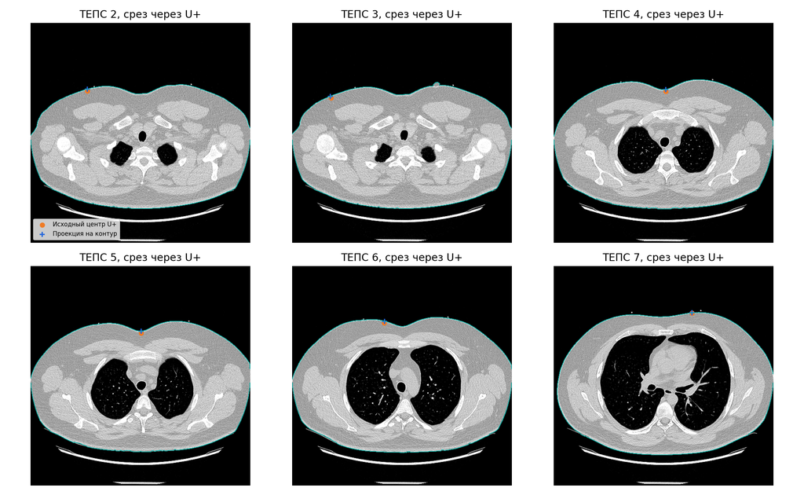

| Монтаж | Контакт | Поправка проекции, мм |
| --- | --- | --- |
| ТЕПС 2 | I+ | 3,3961 |
| ТЕПС 2 | V+ | 3,8561 |
| ТЕПС 2 | V− | 1,3723 |
| ТЕПС 2 | I− | 1,8528 |
| ТЕПС 3 | I+ | 1,3799 |
| ТЕПС 3 | V+ | 3,8255 |
| ТЕПС 3 | V− | 2,3333 |
| ТЕПС 3 | I− | 0,10692 |
| ТЕПС 4 | I+ | 2,983 |
| ТЕПС 4 | V+ | 4,1619 |
| ТЕПС 4 | V− | 1,2843 |
| ТЕПС 4 | I− | 2,3863 |
| ТЕПС 5 | I+ | 4,5394 |
| ТЕПС 5 | V+ | 3,8432 |
| ТЕПС 5 | V− | 1,5591 |
| ТЕПС 5 | I− | 1,5176 |
| ТЕПС 6 | I+ | 2,0833 |
| ТЕПС 6 | V+ | 3,651 |
| ТЕПС 6 | V− | 2,0948 |
| ТЕПС 6 | I− | 0,68416 |
| ТЕПС 7 | I+ | 2,0081 |
| ТЕПС 7 | V+ | 0,7012 |
| ТЕПС 7 | V− | 1,6578 |
| ТЕПС 7 | I− | 2,7984 |

## 7. Новый прямой FEM-расчёт

Геометрия и тканевое разбиение закреплены общим паспортом модели Георгия. Ноутбук читает готовые результаты и не выполняет FEM. Все расчёты используют сердце, лёгкие, кости, жир и оставшийся мягкотканный фон. Для искусственных продолжений рук принят мягкотканный фон: их состав по КТ неизвестен. КТ соответствует глубокому вдоху.

Опорные сопротивления взяты из частотных значений Габриэля при 100 кГц в общем реестре: фон заменён мышечной тканью, лёгкое соответствует вдоху, вся маска сердца — миокарду, вся костная маска — кортикальной кости. Это литературные допущения прямого расчёта; индивидуальные сопротивления Георгия ещё не восстановлены. Проводимость задана скалярной действительной величиной; анизотропия и ёмкостная составляющая тканей в этой постановке не учитываются.

Объёмные сетки построены TetGen по одной и той же проверенной полигональной границе. Ограничения максимального объёма элементов указаны в таблице; это параметры сеточного генератора, а не равномерный шаг сетки. Вокруг всех проверяемых центров рёбра границы разделены до длины не более 0,7 мм. Координаты исходной границы при этом сохранены. Тканевые доли каждого элемента получены по 256 и 1024 точкам последовательности Соболя; их сумма равна единице. Пересечения автоматических масок разрешены в порядке приоритета: лёгкие, кости, сердце, жир, фон. Это правило назначения материала сохранено в паспорте.

Для каждого физического контакта принят диск диаметром 5 мм, площадь 19,635 мм². Фактическая площадь неизвестна. Удельное контактное сопротивление CEM равно 0,000159154943 Ом·м². Это прежний расчётный сценарий проекта; параметр не измерен на Scorpion. Контакты одной электрической группы эквипотенциальны. Для ТЕПС в модель включены четыре размеченных контакта. Неизвестный дополнительный одновременный монтаж не добавлен произвольно; его присутствие потребует отдельной CEM-постановки. Расчётный знак соответствует I+ → I− и U+ − U−. В сценариях совместного подключения боковой сборки и ТТРКГ возбуждается одна токовая пара; остальным электрическим группам задан нулевой суммарный ток. Это постановка прямого расчёта. Её соответствие одновременному зондированию двух каналов Scorpion отдельно не установлено.

**Таблица 3.** Импедансы шести ручных реконструкций в литературном сценарии и численные проверки. Невязка относится к линейной системе FEM; ошибка взаимности — к перестановке токовой и измерительной пар; разность интегрирования — к двум правилам отображения масок. Эти проверки не подтверждают физическую адекватность тканей или приборной схемы.

| Монтаж | Z, Ом | Невязка системы | Ошибка взаимности, Ом | Разность интегрирования, Ом |
| --- | --- | --- | --- | --- |
| ТЕПС 2 | 85,797 | 4,6178·10⁻¹¹ | 0 | 0,067937 |
| ТЕПС 3 | 40,707 | 2,2153·10⁻¹⁰ | 7,1054·10⁻¹⁵ | 0,027646 |
| ТЕПС 4 | 61,116 | 2,2857·10⁻¹¹ | 3,5527·10⁻¹⁴ | 0,075246 |
| ТЕПС 5 | 155,26 | 1,1927·10⁻¹¹ | 2,8422·10⁻¹⁴ | 0,04033 |
| ТЕПС 6 | 43,702 | 3,6353·10⁻¹¹ | 7,1054·10⁻¹⁵ | 0,0090975 |
| ТЕПС 7 | 2,5352 | 5,9728·10⁻¹² | 1,3323·10⁻¹⁵ | 0,00073921 |

**Таблица 4.** Сетки после локального сгущения, фактические опорные сопротивления и сравнение импедансов. Принятый допуск сравнения сеток равен 0,02 Ом + 0,5% от модуля импеданса более плотной сетки. Допуск сравнения интегрирования равен 0,02 Ом + 0,1%. Это критерии численной проверки данной постановки. Сравнение двух сеток охватывает исходные ТЕПС, монтажи рук и иллюстративные боковые сборки; оно не доказывает сходимость для любого нового положения.

| Ограничение объёма элемента, мм³ | Узлы | Тетраэдры | Минимальный объём, мм³ | Объём модели, мл |
| --- | --- | --- | --- | --- |
| 85,333 | 529529 | 1579678 | 7,7021·10⁻¹⁰ | 39106 |
| 36 | 619319 | 2135211 | 7,7021·10⁻¹⁰ | 39106 |
| 10,667 | 1000352 | 4500887 | 2,0985·10⁻¹³ | 39106 |

| Область | Опорное сопротивление, Ом·м |
| --- | --- |
| Мягкотканный фон | 2,7636 |
| Лёгкие | 9,3153 |
| Кости | 48,098 |
| Сердце | 4,6488 |
| Жир | 23,041 |

| Монтаж | Разность сеток, Ом | Принятый численный допуск, Ом | Критерий выполнен |
| --- | --- | --- | --- |
| ТЕПС 2 | 2,983 | 0,44898 | Нет |
| ТЕПС 3 | 0,12672 | 0,22354 | Да |
| ТЕПС 4 | 1,3516 | 0,32558 | Нет |
| ТЕПС 5 | 3,2172 | 0,79628 | Нет |
| ТЕПС 6 | 0,75724 | 0,23851 | Нет |
| ТЕПС 7 | 0,023082 | 0,032676 | Да |
| ТТРКГ 1×1 | 1,0859 | 0,49571 | Нет |
| ТТРКГ 1×4 | 1,4547 | 0,43511 | Нет |
| ТТРКГ 2×2 | 1,7024 | 0,4604 | Нет |
| Боковая 60 мм (ТТРКГ подключена) | 1,3894 | 0,81416 | Нет |
| ТТРКГ 1×4 (боковая 60 мм подключена) | 1,4548 | 0,4351 | Нет |
| Боковая 80 мм (ТТРКГ подключена) | 2,8808 | 0,66213 | Нет |
| ТТРКГ 1×4 (боковая 80 мм подключена) | 1,4546 | 0,43509 | Нет |
| Боковая 100 мм (ТТРКГ подключена) | 3,3989 | 0,52848 | Нет |
| ТТРКГ 1×4 (боковая 100 мм подключена) | 1,4547 | 0,43508 | Нет |
| Боковая 120 мм (ТТРКГ подключена) | 2,5393 | 0,43639 | Нет |
| ТТРКГ 1×4 (боковая 120 мм подключена) | 1,4544 | 0,43507 | Нет |
| Боковая 140 мм (ТТРКГ подключена) | 1,8402 | 0,32432 | Нет |
| ТТРКГ 1×4 (боковая 140 мм подключена) | 1,4537 | 0,43503 | Нет |

| Монтаж | Сетка 6 мм — Z, Ом | Сетка 4 мм — Z, Ом | Разность сеток, Ом | Принятый численный допуск, Ом | Критерий выполнен |
| --- | --- | --- | --- | --- | --- |
| ТЕПС 2 | 85,797 | 86,502 | 0,70584 | 0,45251 | Нет |
| ТЕПС 3 | 40,707 | 40,965 | 0,25769 | 0,22482 | Нет |
| ТЕПС 4 | 61,116 | 62,456 | 1,3401 | 0,33228 | Нет |
| ТЕПС 5 | 155,26 | 160,1 | 4,8463 | 0,82051 | Нет |
| ТЕПС 6 | 43,702 | 44,695 | 0,99314 | 0,24348 | Нет |
| ТЕПС 7 | 2,5352 | 2,6437 | 0,10852 | 0,033219 | Нет |
| ТТРКГ 1×1 | 95,143 | 97,022 | 1,8799 | 0,50511 | Нет |
| ТТРКГ 1×4 | 83,022 | 83,823 | 0,80095 | 0,43911 | Нет |
| ТТРКГ 2×2 | 88,079 | 88,678 | 0,59843 | 0,46339 | Нет |
| Боковая 60 мм (ТТРКГ подключена) | 158,83 | 163,37 | 4,5365 | 0,83684 | Нет |
| ТТРКГ 1×4 (боковая 60 мм подключена) | 83,019 | 83,821 | 0,80111 | 0,4391 | Нет |
| Боковая 80 мм (ТТРКГ подключена) | 128,43 | 129,8 | 1,3771 | 0,66902 | Нет |
| ТТРКГ 1×4 (боковая 80 мм подключена) | 83,019 | 83,82 | 0,80107 | 0,4391 | Нет |
| Боковая 100 мм (ТТРКГ подключена) | 101,7 | 103,14 | 1,4475 | 0,53572 | Нет |
| ТТРКГ 1×4 (боковая 100 мм подключена) | 83,017 | 83,818 | 0,80121 | 0,43909 | Нет |
| Боковая 120 мм (ТТРКГ подключена) | 83,278 | 84,374 | 1,0959 | 0,44187 | Нет |
| ТТРКГ 1×4 (боковая 120 мм подключена) | 83,014 | 83,815 | 0,8013 | 0,43908 | Нет |
| Боковая 140 мм (ТТРКГ подключена) | 60,863 | 61,603 | 0,73954 | 0,32801 | Нет |
| ТТРКГ 1×4 (боковая 140 мм подключена) | 83,007 | 83,808 | 0,80155 | 0,43904 | Нет |

Первая пара сеток, с ограничениями объёма элемента 85,333 и 36 мм³, не удовлетворила этому допуску в 17 из 19 исходных случаев. Наибольшее относительное расхождение составило около 3,48% для ТЕПС 2. Площадки контактов на двух сетках совпали: расхождение возникло при объёмной дискретизации и отображении тканей. Этот отрицательный результат сохранён в таблице 4; первая сетка не принята численным референсом. Дополнительная проверка сеток с параметрами 6 и 4 мм также не выполнила допуск в 19 из 19 случаев. Наибольшее относительное расхождение — 4,1% для монтажа «ТЕПС 7». Сценарии смещения на третьей сетке не пересчитывались.

На выбранной сетке выполнены 163 сценария: 150 для шести монтажей ТЕПС, три монтажа на руках и десять сценариев пяти боковых размеров с ТТРКГ. Для всех этих случаев ошибка площади каждого дискретного контакта не превышает 1,51%, смещение центроида относительно заданного центра — 0,80 мм. На выбранной сетке критерий сравнения интегрирования выполнен для всех исходных случаев; на первой сетке его не выполнил ТЕПС 5. Алгебраические проверки не устраняют выявленное расхождение объёмной дискретизации.

После локального сгущения третья сетка содержит 120 элементов объёмом менее 10⁻¹² мм³. Для каждого знак и объём повторно проверены по точным значениям записанных координат с 80 десятичными знаками. Все объёмы положительны; наибольшее относительное расхождение с вычислением двойной точности — 7,89·10⁻¹². Элементы сохранены, общий объём не изменился. Эта проверка исключает ошибочное удаление малых положительных элементов, но не устанавливает точность FEM-импеданса; она оценивается отдельными сеточными сравнениями.

**Таблица 5.** Локальные чувствительности к свойствам пяти областей: Jᵢ = ∂Z/∂ln ρᵢ, в Ом. При малом относительном изменении сопротивления δρᵢ/ρᵢ ожидаемое изменение импеданса равно Jᵢ·δρᵢ/ρᵢ. Производные вычислены при неизменных геометрии и свойствах остальных областей; для одного исходного монтажа все пять производных проверены центральными конечными разностями. Эти величины характеризуют выбранную прямую модель; они не являются долями объёма или измеренными пульсовыми вкладами тканей.

| Монтаж | Фон — J, Ом | Лёгкие — J, Ом | Кости — J, Ом | Сердце — J, Ом | Жир — J, Ом |
| --- | --- | --- | --- | --- | --- |
| ТЕПС 2 | 37,733 | 4,1232 | 0,20098 | 1,1154 | 42,694 |
| ТЕПС 3 | 26,985 | 3,7287 | 0,28977 | 0,30352 | 9,3861 |
| ТЕПС 4 | 30,644 | 3,1863 | 0,19927 | 1,1349 | 26,289 |
| ТЕПС 5 | 74,808 | 2,2702 | 0,57631 | 0,60611 | 76,11 |
| ТЕПС 6 | 14,296 | 3,1868 | 0,22869 | 0,69753 | 25,299 |
| ТЕПС 7 | 0,95528 | 0,3861 | 0,010411 | 0,10975 | 1,0751 |

Для шести исходных ТЕПС матрица чувствительности к логарифмам сопротивлений фона, лёгких и жира имеет число обусловленности 30. Это локальная невзвешенная оценка при фиксированных положении, костях и сердце. Она не доказывает идентифицируемость сопротивлений при неизвестной установке, погрешности измерений и расхождении анатомической модели.

**Рисунок 5.** Фактические граничные треугольники конечных контактов. Оранжевые площадки — токовые I+ и I−, синие — измерительные U+ и U−. Кнопки выбирают монтаж; ракурс сохраняется. Это площадки, использованные при сборке CEM, а не условные маркеры центров.

[interactive chart not shown]

## 8. Неопределённость установки

Для ТЕПС проверены совместные смещения всех четырёх контактов на 1, 3, 5 и 10 мм в двух локальных касательных направлениях с обоими знаками. Каждый контакт повторно спроецирован на поверхность; площадки и контактные матрицы пересобраны. Дополнительно проверены отдельные продольные смещения каждого контакта на ±5 мм. Заданные амплитуды не являются доверительными интервалами неизвестной погрешности ручной установки.

Все показанные смещения относятся к сетке, указанной общим паспортом модели. Сходимость каждого смещённого положения на независимой сетке отдельно не доказана; при незавершённой сеточной проверке эти зависимости показывают исследовательские сценарии, а не гарантированный предел погрешности.

Для ТЕПС 5 наименьшее расстояние между исходными центрами равно 12,8 мм. Отдельный сдвиг центра I− на +5 мм с повторной проекцией изменил Z с 155,26 до 224,87 Ом, то есть на 69,62 Ом. Фактическое перемещение спроецированного центра составило 5,20 мм. Этот пример показывает необходимость учитывать ошибку отдельных контактов; величина не является измеренной ошибкой установки или доказанным расхождением с записью.

**Рисунок 6.** Каждая цветная линия соответствует одному монтажу ТЕПС. Кружки показывают наибольшее абсолютное изменение импеданса среди четырёх совместных направлений при данной амплитуде; соединяющие сплошные отрезки служат для чтения дискретных результатов. Между отмеченными амплитудами расчёты не выполнены. Легенда позволяет отключать монтажи. Это чувствительность прямой модели при фиксированных литературных сопротивлениях; она не заменяет совместную обратную задачу положения и свойств тканей.

Новая геометрия является общим входом дальнейших расчётов. Статус численной точности сохраняется отдельно и проверяется до количественной инверсии. Полная локализация боковых сборок, идентификация сопротивлений, сопоставление с принятыми фазами записей и независимая проверка УО/ФВ остаются отдельными этапами.

[interactive chart not shown]

**Таблица 6.** Разность импеданса при отдельном смещении каждого контакта на ±5 мм относительно исходного монтажа. Смещение задаётся вдоль проекции оси z LPS на локальную касательную плоскость, после чего центр возвращается ближайшей проекцией на поверхность. Знак разности показывает направление изменения Z. Совместный перенос и ошибка одного контакта проверяются раздельно: они меняют взаимные расстояния и поле тока различным образом.

| Монтаж | Смещённый контакт | Смещение по касательной, мм | Изменение Z, Ом |
| --- | --- | --- | --- |
| ТЕПС 2 | I+ | -5 | 6,4711 |
| ТЕПС 2 | I+ | 5 | −6,1076 |
| ТЕПС 2 | V+ | -5 | −4,9508 |
| ТЕПС 2 | V+ | 5 | 5,1079 |
| ТЕПС 2 | V− | -5 | 5,945 |
| ТЕПС 2 | V− | 5 | −5,3417 |
| ТЕПС 2 | I− | -5 | −4,7794 |
| ТЕПС 2 | I− | 5 | 5,5782 |
| ТЕПС 3 | I+ | -5 | 1,681 |
| ТЕПС 3 | I+ | 5 | −1,9609 |
| ТЕПС 3 | V+ | -5 | −0,63257 |
| ТЕПС 3 | V+ | 5 | 0,67798 |
| ТЕПС 3 | V− | -5 | −0,52099 |
| ТЕПС 3 | V− | 5 | 0,57233 |
| ТЕПС 3 | I− | -5 | −0,26154 |
| ТЕПС 3 | I− | 5 | 0,29125 |
| ТЕПС 4 | I+ | -5 | 8,941 |
| ТЕПС 4 | I+ | 5 | −11,885 |
| ТЕПС 4 | V+ | -5 | −6,7475 |
| ТЕПС 4 | V+ | 5 | 9,38 |
| ТЕПС 4 | V− | -5 | 4,0349 |
| ТЕПС 4 | V− | 5 | −3,4411 |
| ТЕПС 4 | I− | -5 | −2,2989 |
| ТЕПС 4 | I− | 5 | 2,7168 |
| ТЕПС 5 | I+ | -5 | 12,979 |
| ТЕПС 5 | I+ | 5 | −11,724 |
| ТЕПС 5 | V+ | -5 | −10,559 |
| ТЕПС 5 | V+ | 5 | 14,391 |
| ТЕПС 5 | V− | -5 | 55,66 |
| ТЕПС 5 | V− | 5 | −31,966 |
| ТЕПС 5 | I− | -5 | −33,321 |
| ТЕПС 5 | I− | 5 | 69,616 |
| ТЕПС 6 | I+ | -5 | −3,2781 |
| ТЕПС 6 | I+ | 5 | 4,9408 |
| ТЕПС 6 | V+ | -5 | 2,9664 |
| ТЕПС 6 | V+ | 5 | −2,4425 |
| ТЕПС 6 | V− | -5 | 3,9044 |
| ТЕПС 6 | V− | 5 | −3,5432 |
| ТЕПС 6 | I− | -5 | −3,6683 |
| ТЕПС 6 | I− | 5 | 5,1443 |
| ТЕПС 7 | I+ | -5 | 0,12101 |
| ТЕПС 7 | I+ | 5 | −0,20261 |
| ТЕПС 7 | V+ | -5 | 0,25016 |
| ТЕПС 7 | V+ | 5 | −0,28682 |
| ТЕПС 7 | V− | -5 | −0,075931 |
| ТЕПС 7 | V− | 5 | 0,043741 |
| ТЕПС 7 | I− | -5 | −0,16539 |
| ТЕПС 7 | I− | 5 | 0,22569 |